# Task 1: Dataset Characterization and Preprocessing

# Task 3: Deep Anomaly Detection and Data Representation

## Training and Validating Autoencoder with Normal data only: Create an AutoEncoder architecture. Autonomously choose the implementation details: the only requirement is that the architecture must have a shrinking encoder and an expansion decoder,with a bottleneck in between. Use normal data only; split the normal data into training and validation sets, and use the validation set to pick the best number of epochs and learning rate.

```python
#import necessary libraries for deep learning
from torch.utils.data import TensorDataset, DataLoader
import torch.nn.functional as F
import torch.optim as optim
import torch.nn as nn
import torch
```

### define autoencoder according to requirement

```python
class ImprovedAutoencoder(nn.Module):
    def __init__(self, input_dim, bottleneck_dim=16):
        super(ImprovedAutoencoder, self).__init__()

        # Encoder: deeper network, batchnorm, dropout
        self.encoder = nn.Sequential(
            nn.Linear(input_dim, 128),
            nn.BatchNorm1d(128),
            nn.ReLU(),
            nn.Dropout(0.2),

            nn.Linear(128, 64),
            nn.BatchNorm1d(64),
            nn.ReLU(),
            nn.Dropout(0.2),

            nn.Linear(64, bottleneck_dim)
        )

        # Decoder: symmetric structure
        self.decoder = nn.Sequential(
            nn.Linear(bottleneck_dim, 64),
            nn.BatchNorm1d(64),
            nn.ReLU(),
            nn.Dropout(0.2),

            nn.Linear(64, 128),
            nn.BatchNorm1d(128),
            nn.ReLU(),
            nn.Dropout(0.2),

            nn.Linear(128, input_dim)
        )

    def forward(self, x):
        z = self.encoder(x)     # bottleneck representation
        x_hat = self.decoder(z) # reconstruction
        return x_hat

    def encode(self, x):
        return self.encoder(x)  # return bottleneck representation
```

### split the normal data into training and validation sets

```python
# === 1. Prepare Data for Autoencoder Training ===
# 2. Convert the split data (NumPy/Pandas) into PyTorch Tensors
# We use float32 as it is the standard data type for neural network computations in PyTorch.
X_train_tensor_normal_only = torch.tensor(X_train_normal_only.values, dtype=torch.float32)
X_val_tensor_normal_only = torch.tensor(X_val_normal_only.values, dtype=torch.float32)

# 3. Encapsulate Tensors into DataLoaders for efficient batch processing
# batch_size=64: The model will update its weights after seeing 64 samples at a time.
# shuffle=True: Shuffling the training set prevents the model from learning the order of data.
train_loader_normal_only = DataLoader(
    TensorDataset(X_train_tensor_normal_only),
    batch_size=64,
    shuffle=True
)

# shuffle=False: Validation data doesn't need shuffling as we are only evaluating performance.
val_loader_normal_only = DataLoader(
    TensorDataset(X_val_tensor_normal_only),
    batch_size=64,
    shuffle=False
)
```

### Train the Autoencoder

```python
def mixed_autoencoder_loss(x, x_recon, categorical_dims, numerical_idx):
    """
    Args:
        x: original input [batch_size, num_features]
        x_recon: reconstructed input [batch_size, num_features]
        categorical_dims: list of (start_idx, end_idx) tuples for one-hot encoded categorical features
        numerical_idx: list of indices for numerical features

    Returns:
        Scalar loss value (MSE + sum of CE)
    """
    # Numerical loss (MSE)
    x_num = x[:, numerical_idx]
    x_recon_num = x_recon[:, numerical_idx]
    mse = F.mse_loss(x_recon_num, x_num)

    # Categorical loss (CE for each one-hot feature)
    ce = 0
    for start, end in categorical_dims:
        x_cat = x[:, start:end]
        x_recon_cat = x_recon[:, start:end]

        # CE expects class indices as targets
        target = torch.argmax(x_cat, dim=1)
        ce += F.cross_entropy(x_recon_cat, target)

    return mse + ce
```

```python
def compute_per_sample_reconstruction_error(x, x_recon, categorical_dims, numerical_idx):
    """
    Returns a vector [batch_size] with the total reconstruction error (MSE + sum CE) for each sample
    """
    batch_size = x.shape[0]

    # Numerical error per sample
    x_num = x[:, numerical_idx]
    x_recon_num = x_recon[:, numerical_idx]
    mse_per_sample = torch.mean((x_num - x_recon_num) ** 2, dim=1)

    # Categorical CE error per sample (sum across categorical features)
    ce_total = torch.zeros(batch_size, device=x.device)
    for start, end in categorical_dims:
        x_cat = x[:, start:end]
        x_recon_cat = x_recon[:, start:end]

        target = torch.argmax(x_cat, dim=1)
        ce = F.cross_entropy(x_recon_cat, target, reduction='none')  # shape: [batch_size]
        ce_total += ce

    # Total reconstruction error per sample
    return mse_per_sample + ce_total
```

```python
#Indexes to compute the loss function based on MSE and CE for categorical features
# Step 1: Get all column names
all_columns = [col for col in df_train_preprocessed.columns if col not in ['label', 'binary_label']]

# Step 2: Get categorical index ranges
categorical_cols = ['protocol_type', 'service', 'flag']
categorical_dims = []
for col in categorical_cols:
    # Get all one-hot columns for this categorical feature
    one_hot_cols = [c for c in all_columns if c.startswith(col + "_")]
    if one_hot_cols:
        start_idx = all_columns.index(one_hot_cols[0])
        end_idx = start_idx + len(one_hot_cols)
        categorical_dims.append((start_idx, end_idx))

# Step 3: Get numerical column indexes
numerical_idx = [i for i, col in enumerate(all_columns)
                 if not any(col.startswith(c + "_") for c in categorical_cols)]
```

```python
import copy

def train_and_validate_ae(model, train_loader, val_loader, n_epochs, learning_rate,
                          categorical_dims, numerical_idx, device):
    """
    Trains the autoencoder and validates it to find the best model state.

    Returns:
        best_model: The model with the lowest validation loss.
        history: Dictionary containing training and validation loss per epoch.
    """
    # 1. Initialize Optimizer (Default to Adam as requested)
    optimizer = torch.optim.Adam(model.parameters(), lr=learning_rate)

    # 2. Tracking variables
    best_val_loss = float('inf') # Set to infinity so any first loss will be lower
    best_model_state = None      # To store the weights of the best version
    history = {'train': [], 'val': []}

    model.to(device)

    for epoch in range(n_epochs):
        # --- TRAINING PHASE ---
        model.train() # Enable Dropout and BatchNorm
        train_running_loss = 0.0

        for batch in train_loader:
            x_batch = batch[0].to(device)

            optimizer.zero_grad()
            x_hat = model(x_batch)
            loss = mixed_autoencoder_loss(x_batch, x_hat, categorical_dims, numerical_idx)

            loss.backward()
            optimizer.step()

            # Multiply by batch size because F.mse_loss/cross_entropy usually returns average
            train_running_loss += loss.item() * x_batch.size(0)

        epoch_train_loss = train_running_loss / len(train_loader.dataset)
        history['train'].append(epoch_train_loss)

        # --- VALIDATION PHASE ---
        model.eval() # Disable Dropout and use running stats for BatchNorm
        val_running_loss = 0.0

        with torch.no_grad(): # No gradient calculation saves memory and time
            for batch in val_loader:
                x_val = batch[0].to(device)
                x_hat_val = model(x_val)
                v_loss = mixed_autoencoder_loss(x_val, x_hat_val, categorical_dims, numerical_idx)

                val_running_loss += v_loss.item() * x_val.size(0)

        epoch_val_loss = val_running_loss / len(val_loader.dataset)
        history['val'].append(epoch_val_loss)

        # --- MODEL CHECKPOINTING ---
        # If the current validation loss is the best we've seen, save the state
        if epoch_val_loss < best_val_loss:
            best_val_loss = epoch_val_loss
            # deepcopy is used to capture the state at this specific moment
            best_model_state = copy.deepcopy(model.state_dict())
            print(f"Epoch {epoch+1}: New best model found! (Val Loss: {epoch_val_loss:.6f})")

        if (epoch + 1) % 5 == 0 or epoch == 0:
            print(f"Epoch {epoch+1}/{n_epochs} -> Train Loss: {epoch_train_loss:.6f} | Val Loss: {epoch_val_loss:.6f}")

    # Load the best weights back into the model before returning
    if best_model_state:
        model.load_state_dict(best_model_state)

    return model, history
```

```python
import random
# Set seeds
seed = 69
random.seed(seed)
np.random.seed(seed)
torch.manual_seed(seed)
torch.cuda.manual_seed_all(seed)
```

```
Input dimension for Autoencoder: 52

========================================
EXPERIMENT: Learning Rate = 0.01
========================================
Epoch 1: New best model found! (Val Loss: 0.381524)
Epoch 2: New best model found! (Val Loss: 0.377582)
Epoch 3: New best model found! (Val Loss: 0.315472)
Epoch 5: New best model found! (Val Loss: 0.290995)
Epoch 10: New best model found! (Val Loss: 0.275700)
Epoch 11: New best model found! (Val Loss: 0.266807)
Epoch 14: New best model found! (Val Loss: 0.262608)
Epoch 17: New best model found! (Val Loss: 0.254691)
Epoch 19: New best model found! (Val Loss: 0.233854)
Epoch 23: New best model found! (Val Loss: 0.198212)
Epoch 24: New best model found! (Val Loss: 0.188660)
Epoch 27: New best model found! (Val Loss: 0.188656)
Epoch 28: New best model found! (Val Loss: 0.184837)
Epoch 40: New best model found! (Val Loss: 0.166651)
Epoch 82: New best model found! (Val Loss: 0.159170)
Epoch 85: New best model found! (Val Loss: 0.158841)
Epoch 99: New best model found! (Val Loss: 0.128724)
```

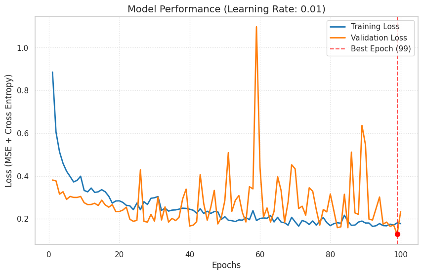

```
Successfully saved plot: loss_curve_lr_0.01.pdf

========================================
EXPERIMENT: Learning Rate = 0.001
========================================
Epoch 1: New best model found! (Val Loss: 0.536544)
Epoch 2: New best model found! (Val Loss: 0.360234)
Epoch 3: New best model found! (Val Loss: 0.318085)
Epoch 5: New best model found! (Val Loss: 0.288814)
Epoch 6: New best model found! (Val Loss: 0.282050)
Epoch 7: New best model found! (Val Loss: 0.276297)
Epoch 9: New best model found! (Val Loss: 0.251561)
Epoch 10: New best model found! (Val Loss: 0.240169)
Epoch 11: New best model found! (Val Loss: 0.234292)
Epoch 13: New best model found! (Val Loss: 0.215580)
Epoch 15: New best model found! (Val Loss: 0.202040)
Epoch 19: New best model found! (Val Loss: 0.194904)
Epoch 21: New best model found! (Val Loss: 0.183436)
Epoch 23: New best model found! (Val Loss: 0.177662)
Epoch 26: New best model found! (Val Loss: 0.172765)
Epoch 28: New best model found! (Val Loss: 0.165898)
Epoch 32: New best model found! (Val Loss: 0.132968)
Epoch 59: New best model found! (Val Loss: 0.127399)
Epoch 68: New best model found! (Val Loss: 0.122897)
Epoch 75: New best model found! (Val Loss: 0.117807)
```

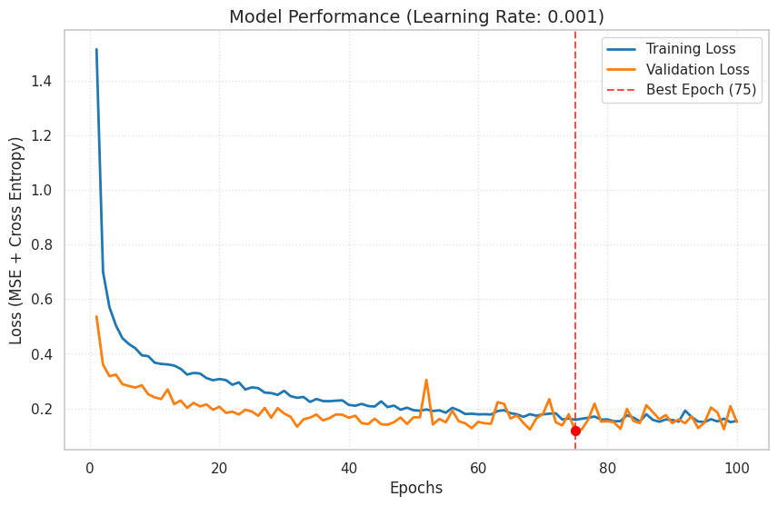

```
Successfully saved plot: loss_curve_lr_0.001.pdf

========================================
EXPERIMENT: Learning Rate = 0.0001
========================================
Epoch 1: New best model found! (Val Loss: 2.776851)
Epoch 2: New best model found! (Val Loss: 1.681050)
Epoch 3: New best model found! (Val Loss: 1.184440)
Epoch 4: New best model found! (Val Loss: 0.970697)
Epoch 5: New best model found! (Val Loss: 0.821659)
Epoch 6: New best model found! (Val Loss: 0.802885)
Epoch 7: New best model found! (Val Loss: 0.648856)
Epoch 8: New best model found! (Val Loss: 0.633587)
Epoch 9: New best model found! (Val Loss: 0.567828)
Epoch 10: New best model found! (Val Loss: 0.533390)
Epoch 11: New best model found! (Val Loss: 0.491969)
Epoch 14: New best model found! (Val Loss: 0.449889)
Epoch 15: New best model found! (Val Loss: 0.410095)
Epoch 17: New best model found! (Val Loss: 0.402507)
Epoch 18: New best model found! (Val Loss: 0.391107)
Epoch 19: New best model found! (Val Loss: 0.349028)
Epoch 21: New best model found! (Val Loss: 0.340285)
Epoch 22: New best model found! (Val Loss: 0.325606)
Epoch 23: New best model found! (Val Loss: 0.321641)
Epoch 24: New best model found! (Val Loss: 0.310321)
Epoch 27: New best model found! (Val Loss: 0.295030)
Epoch 28: New best model found! (Val Loss: 0.291068)
Epoch 34: New best model found! (Val Loss: 0.281318)
Epoch 36: New best model found! (Val Loss: 0.276416)
Epoch 38: New best model found! (Val Loss: 0.262345)
Epoch 44: New best model found! (Val Loss: 0.252651)
Epoch 46: New best model found! (Val Loss: 0.249373)
Epoch 47: New best model found! (Val Loss: 0.247780)
Epoch 48: New best model found! (Val Loss: 0.240748)
Epoch 59: New best model found! (Val Loss: 0.235206)
Epoch 61: New best model found! (Val Loss: 0.233753)
Epoch 65: New best model found! (Val Loss: 0.228430)
Epoch 74: New best model found! (Val Loss: 0.221416)
Epoch 82: New best model found! (Val Loss: 0.217122)
Epoch 84: New best model found! (Val Loss: 0.213240)
Epoch 88: New best model found! (Val Loss: 0.212495)
Epoch 98: New best model found! (Val Loss: 0.206812)
```

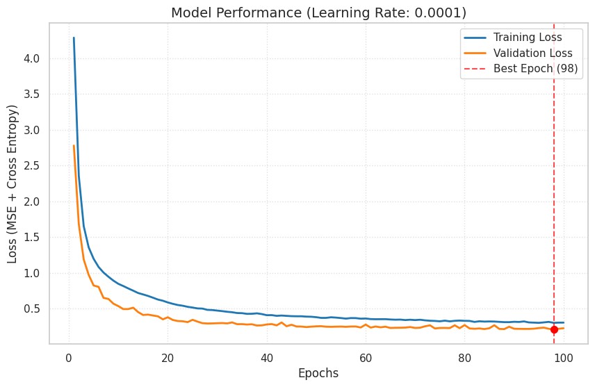

```
Successfully saved plot: loss_curve_lr_0.0001.pdf

----------- GRID SEARCH FINAL SUMMARY ------------
Winning Learning Rate: 0.001
Optimal Stopping Epoch: 75
Global Minimum Validation Loss: 0.117807
--------------------------------------------------
```

```python
import matplotlib.pyplot as plt

# --- Setup Search Space ---
candidate_lrs = [0.01, 0.001, 0.0001]
max_epochs = 100
device = torch.device("cuda" if torch.cuda.is_available() else "cpu")

best_overall_val_loss = float('inf')
best_lr = None
best_epoch_num = None
final_best_model = None
input_dim = X_train_normal_only.shape[1]  # Number of features after preprocessing
print(f"Input dimension for Autoencoder: {input_dim}")

# Iterate through learning rate candidates
for lr in candidate_lrs:
    print(f"\n" + "="*40)
    print(f"EXPERIMENT: Learning Rate = {lr}")
    print("="*40)

    # Initialize a fresh model instance for each experiment
    model_to_test = ImprovedAutoencoder(input_dim=input_dim, bottleneck_dim=16).to(device)

    # Run training and validation
    trained_model, history = train_and_validate_ae(
        model=model_to_test,
        train_loader=train_loader_normal_only,
        val_loader=val_loader_normal_only,
        n_epochs=max_epochs,
        learning_rate=lr,
        categorical_dims=categorical_dims,
        numerical_idx=numerical_idx,
        device=device
    )

    # --- Identify Best Epoch for this specific LR ---
    min_val_loss = min(history['val'])
    best_epoch_idx = history['val'].index(min_val_loss) + 1 # +1 for 1-based epoch numbering

    # --- Visualization and Export Section ---
    plt.figure(figsize=(10, 6))
    epochs_range = range(1, len(history['train']) + 1)

    # Plot training and validation loss curves
    plt.plot(epochs_range, history['train'], label='Training Loss', color='#1f77b4', linewidth=2)
    plt.plot(epochs_range, history['val'], label='Validation Loss', color='#ff7f0e', linewidth=2)

    # Draw a vertical dashed line at the "Best Epoch"
    plt.axvline(x=best_epoch_idx, color='red', linestyle='--', alpha=0.7, label=f'Best Epoch ({best_epoch_idx})')

    # Add a marker at the minimum point
    plt.scatter(best_epoch_idx, min_val_loss, color='red', s=50, zorder=5)

    # Formatting the plot
    plt.title(f"Model Performance (Learning Rate: {lr})", fontsize=14)
    plt.xlabel("Epochs", fontsize=12)
    plt.ylabel("Loss (MSE + Cross Entropy)", fontsize=12)
    plt.legend(loc='upper right')
    plt.grid(True, linestyle=':', alpha=0.6)

    # Save the figure as a high-quality PDF
    pdf_filename = f"loss_curve_lr_{lr}.pdf"
    plt.savefig(pdf_filename, format='pdf', bbox_inches='tight')
    plt.show() # Display in the notebook/console
    print(f"Successfully saved plot: {pdf_filename}")

    # --- Global Leaderboard Tracking ---
    if min_val_loss < best_overall_val_loss:
        best_overall_val_loss = min_val_loss
        best_lr = lr
        best_epoch_num = best_epoch_idx
        final_best_model = trained_model

# Final Summary Report
print("\n" + " GRID SEARCH FINAL SUMMARY ".center(50, "-"))
print(f"Winning Learning Rate: {best_lr}")
print(f"Optimal Stopping Epoch: {best_epoch_num}")
print(f"Global Minimum Validation Loss: {best_overall_val_loss:.6f}")
print("-" * 50)
```

```python
import matplotlib.pyplot as plt
import numpy as np

def estimate_reconstruction_threshold(reconstruction_error, percentile=95, plot=True, v_max_ratio=0.995, pdf_name=None, labels=None):
    """
    Estimates thresholds and plots ECDF for multiple error sets with custom labels.

    Parameters:
    -----------
    reconstruction_error : np.ndarray, list of np.ndarrays, or dict
        The error data. If dict, keys are used as labels.
    labels : list of str, optional
        Custom names for the curves if reconstruction_error is a list.
    """

    # --- 1. Data Normalization (Handling labels) ---
    if isinstance(reconstruction_error, dict):
        data_dict = reconstruction_error
    elif isinstance(reconstruction_error, list):
        if labels and len(labels) == len(reconstruction_error):
            data_dict = {labels[i]: np.array(err) for i, err in enumerate(reconstruction_error)}
        else:
            data_dict = {f"Set {i+1}": np.array(err) for i, err in enumerate(reconstruction_error)}
    else:
        # Single array case
        label = labels[0] if (labels and isinstance(labels, list)) else "Data"
        data_dict = {label: np.array(reconstruction_error)}

    thresholds = {}
    for label, err in data_dict.items():
        thresholds[label] = np.percentile(err, percentile)
        print(f"--- Statistics for [{label}] ---")
        print(f"Min: {np.min(err):.4f} | Max: {np.max(err):.4f} | Mean: {np.mean(err):.4f} | Median: {np.median(err):.4f}")
        print(f"Threshold ({percentile}%): {thresholds[label]:.4f}\n")

    if plot:
        # --- 2. GIGANTIC Font Settings for LaTeX ---
        plt.rcParams.update({
            'font.size': 20,
            'axes.titlesize': 22,
            'axes.labelsize': 20,
            'xtick.labelsize': 18,
            'ytick.labelsize': 18,
            'legend.fontsize': 14,
            'figure.figsize': (10, 6),
            'axes.linewidth': 2.0
        })

        plt.figure()
        # Use a professional color cycle
        prop_cycle = plt.rcParams['axes.prop_cycle']
        colors = prop_cycle.by_key()['color']

        max_x_limit = 0

        for i, (label, err) in enumerate(data_dict.items()):
            color = colors[i % len(colors)]
            sorted_err = np.sort(err)
            n = len(sorted_err)
            y = np.arange(1, n + 1) / n

            # Plot ECDF curve
            plt.step(sorted_err, y, where='post', color=color, linewidth=3.5, label=f'{label} (ECDF)')

            # Plot Threshold line (Dashed)
            plt.axvline(thresholds[label], color=color, linestyle='--', linewidth=3,
                        alpha=0.8, label=f'{label} Thr: {thresholds[label]:.3f}')

            # Calculate X-axis limit
            current_x_limit = np.percentile(err, v_max_ratio * 100)
            max_x_limit = max(max_x_limit, current_x_limit)

        # --- 3. Viewport and Styling ---
        plt.xlim(-0.01 * max_x_limit, max_x_limit)
        plt.ylim(-0.02, 1.05)

        plt.title(pdf_name if pdf_name else "ECDF Threshold Comparison", pad=20)
        plt.xlabel('Reconstruction Error', labelpad=10)
        plt.ylabel('Cumulative Proportion', labelpad=10)

        # Legend with shadow for better readability
        plt.legend(loc='lower right', frameon=True, shadow=True, facecolor='white')
        plt.grid(True, linestyle=':', alpha=0.7)

        # --- 4. Save and Show ---
        if pdf_name:
            if not pdf_name.endswith('.pdf'):
                pdf_name += '.pdf'
            plt.tight_layout()
            plt.savefig(pdf_name, format='pdf', bbox_inches='tight')
            print(f"Plot successfully saved as: {pdf_name}")

        plt.show()

    return thresholds
```

```python
import torch

def calculate_val_reconstruction_error(model, X_tensor, categorical_dims, numerical_idx):
    """
    Computes the reconstruction error for the provided dataset.

    Parameters:
    -----------
    model : torch.nn.Module
        The trained model used for reconstruction.
    X_tensor : torch.Tensor
        The dataset tensor (e.g., validation set).
    categorical_dims : list
        List of categorical dimension information.
    numerical_idx : list
        Indices for numerical features.

    Returns:
    --------
    reconstruction_error : np.ndarray
        The reconstruction error for each sample as a NumPy array.
    """
    # 1. Switch to evaluation mode
    model.eval()

    # 2. Reconstruct the dataset without gradient tracking
    with torch.no_grad():
        # Ensure data is on the same device as the model
        X_tensor = X_tensor.to(next(model.parameters()).device)
        X_reconstructed = model(X_tensor)

        # 3. Calculate per-sample reconstruction error
        reconstruction_error = compute_per_sample_reconstruction_error(
            X_tensor, X_reconstructed,
            categorical_dims=categorical_dims,
            numerical_idx=numerical_idx
        )

    # 4. Convert to NumPy and return
    return reconstruction_error.cpu().numpy()
```

```python
import numpy as np

def calculate_ae_threshold_from_ocsvm_insight(ae_errors, target_fpr=0.05):
    """
    Based on OC-SVM empirical results (nu=0.05), we set the AE threshold
    at the (1 - target_fpr) percentile.
    """
    # 1. Calculate base robust statistics
    median = np.median(ae_errors)
    abs_deviation = np.abs(ae_errors - median)
    mad = np.median(abs_deviation)
    scaled_mad = mad * 1.4826  # Consistency constant

    # 2. Set threshold at the 95th percentile (derived from nu=0.05)
    threshold = np.percentile(ae_errors, (1 - target_fpr) * 100)

    # 3. Back-calculate the sensitivity K to justify with MAD rule
    # Formula: threshold = median + K * scaled_mad
    k_value = (threshold - median) / scaled_mad

    return {
        "threshold": threshold,
        "k_value": k_value,
        "median": median,
        "target_fpr": target_fpr
    }
```

```python
def evaluate_performance(errors, true_labels, threshold):
    pred_labels = (errors > threshold).astype(int)

    # print classification report for detailed metrics
    print(classification_report(true_labels, pred_labels, digits=4))

    return {
        "acc": accuracy_score(true_labels, pred_labels),
        "f1": f1_score(true_labels, pred_labels, zero_division=0)
    }
```

```python
# Switch to evaluation mode
print(final_best_model)
```

```
ImprovedAutoencoder(
  (encoder): Sequential(
    (0): Linear(in_features=52, out_features=128, bias=True)
    (1): BatchNorm1d(128, eps=1e-05, momentum=0.1, affine=True, bias=True, track_running_stats=True)
    (2): ReLU()
    (3): Dropout(p=0.2, inplace=False)
    (4): Linear(in_features=128, out_features=64, bias=True)
    (5): BatchNorm1d(64, eps=1e-05, momentum=0.1, affine=True, bias=True, track_running_stats=True)
    (6): ReLU()
    (7): Dropout(p=0.2, inplace=False)
    (8): Linear(in_features=64, out_features=16, bias=True)
  )
  (decoder): Sequential(
    (0): Linear(in_features=16, out_features=64, bias=True)
    (1): BatchNorm1d(64, eps=1e-05, momentum=0.1, affine=True, bias=True, track_running_stats=True)
    (2): ReLU()
    (3): Dropout(p=0.2, inplace=False)
    (4): Linear(in_features=64, out_features=128, bias=True)
    (5): BatchNorm1d(128, eps=1e-05, momentum=0.1, affine=True, bias=True, track_running_stats=True)
    (6): ReLU()
    (7): Dropout(p=0.2, inplace=False)
    (8): Linear(in_features=128, out_features=52, bias=True)
  )
)
```

```
--- AE Threshold Justified by OC-SVM (nu=0.05) ---
Empirical Target FPR : 5.00%
Calculated Threshold : 0.310451
Implied MAD K-factor : 28.77
Selected AE Threshold for Anomaly Detection: 0.310451
--- Statistics for [Validation (Normal Only)] ---
Min: 0.0009 | Max: 32.2715 | Mean: 0.1178 | Median: 0.0092
Threshold (95%): 0.3105

Plot successfully saved as: val_reconstruction_error_ecdf(normal_only).pdf
```

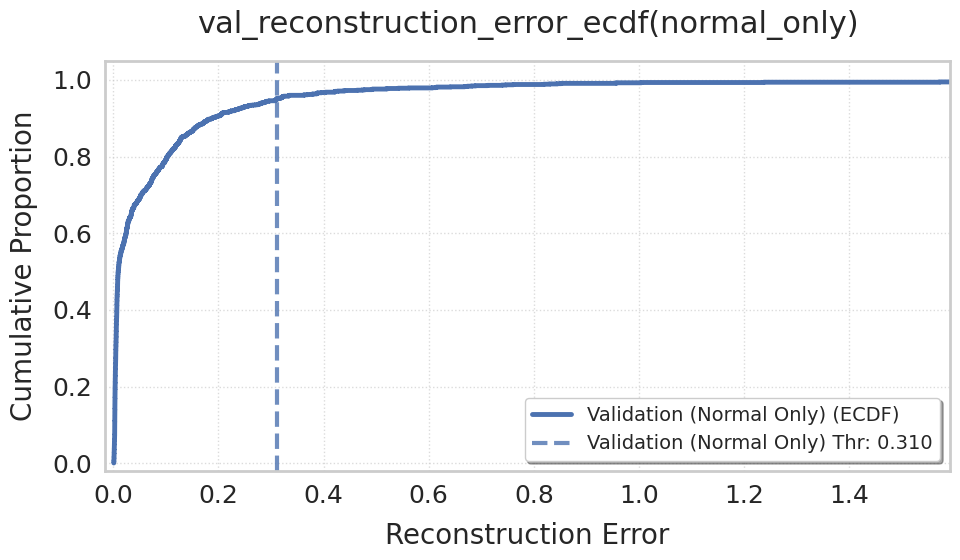

```
{'Validation (Normal Only)': np.float32(0.31045076)}
```

```python
normal_only_val_re = calculate_val_reconstruction_error(
    final_best_model,
    X_val_tensor_normal_only,
    categorical_dims,
    numerical_idx
)

# --- Execution using your AE validation errors ---
ae_results = calculate_ae_threshold_from_ocsvm_insight(normal_only_val_re, target_fpr=0.05)

print(f"--- AE Threshold Justified by OC-SVM (nu=0.05) ---")
print(f"Empirical Target FPR : {ae_results['target_fpr']:.2%}")
print(f"Calculated Threshold : {ae_results['threshold']:.6f}")
print(f"Implied MAD K-factor : {ae_results['k_value']:.2f}")

selected_threshold = ae_results['threshold']
print(f"Selected AE Threshold for Anomaly Detection: {selected_threshold:.6f}")
estimate_reconstruction_threshold(reconstruction_error= {"Validation (Normal Only)": normal_only_val_re}, percentile=95, plot=True, v_max_ratio=0.995, pdf_name="val_reconstruction_error_ecdf(normal_only)")
```

## Anomaly Detection with reconstruction error: Now, use the trained model to compute the reconstruction errors for each point in the full training set (normal data + anomalies) and test set.

```
--- Statistics for [Training (mixed)] ---
Min: 0.0007 | Max: 513.1913 | Mean: 0.9047 | Median: 0.0507
Threshold (95%): 3.5563

Plot successfully saved as: train_reconstruction_error_ecdf.pdf
```

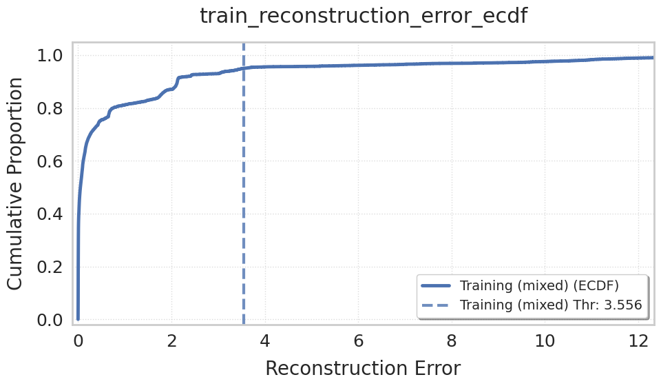

```
{'Training (mixed)': np.float32(3.5562637)}
```

```python
X_train_tensor = torch.tensor(X_train.values, dtype=torch.float32)

full_train_re = calculate_val_reconstruction_error(
    final_best_model,
    X_train_tensor,
    categorical_dims,
    numerical_idx
)

estimate_reconstruction_threshold(reconstruction_error= {"Training (mixed)": full_train_re}, percentile=95,v_max_ratio=0.99, pdf_name="train_reconstruction_error_ecdf")
```

```
--- Statistics for [Testing (mixed)] ---
Min: 0.0018 | Max: 177.6283 | Mean: 2.1254 | Median: 0.7403
Threshold (95%): 10.8390

Plot successfully saved as: test_reconstruction_error_ecdf.pdf
```

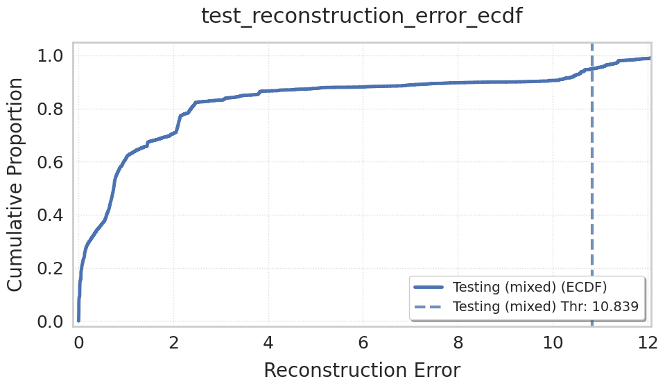

```python
X_test_tensor = torch.tensor(X_test.values, dtype=torch.float32)

full_test_re = calculate_val_reconstruction_error(
    final_best_model,
    X_test_tensor,
    categorical_dims,
    numerical_idx
)

my_threshold = estimate_reconstruction_threshold(reconstruction_error= {"Testing (mixed)": full_test_re}, percentile=95,v_max_ratio=0.99, pdf_name="test_reconstruction_error_ecdf")
```

```
--- Statistics for [Validation (Normal Only)] ---
Min: 0.0009 | Max: 32.2715 | Mean: 0.1178 | Median: 0.0092
Threshold (95%): 0.3105

--- Statistics for [Training (mixed)] ---
Min: 0.0007 | Max: 513.1913 | Mean: 0.9047 | Median: 0.0507
Threshold (95%): 3.5563

--- Statistics for [Testing (mixed)] ---
Min: 0.0018 | Max: 177.6283 | Mean: 2.1254 | Median: 0.7403
Threshold (95%): 10.8390

Plot successfully saved as: val vs train vs test reconstruction error comparison.pdf
```

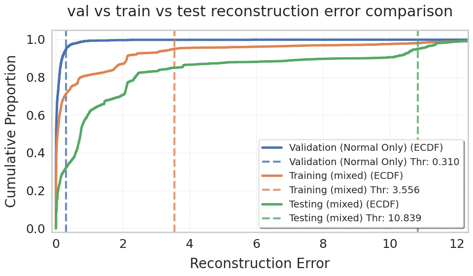

```
{'Validation (Normal Only)': np.float32(0.31045076),
 'Training (mixed)': np.float32(3.5562637),
 'Testing (mixed)': np.float32(10.83903)}
```

```python
estimate_reconstruction_threshold(
    reconstruction_error={
        "Validation (Normal Only)": normal_only_val_re,
        "Training (mixed)": full_train_re,
        "Testing (mixed)": full_test_re
    },
    percentile=95,
    v_max_ratio=0.99,
    pdf_name="val vs train vs test reconstruction error comparison"
)
```

### Use the threshold identified in the previous point to classify anomalies in full validation set, full train set and full test set

```python
X_val_tensor = torch.tensor(X_val.values, dtype=torch.float32)

full_val_re = calculate_val_reconstruction_error(
    final_best_model,
    X_val_tensor,
    categorical_dims,
    numerical_idx
)
print("performance report for full validation set")
evaluate_performance(full_val_re, y_val, selected_threshold)

print("performance report for full training set")
evaluate_performance(full_train_re, y_train, selected_threshold)

print("performance report for full testing set")
evaluate_performance(full_test_re, y_test, selected_threshold)
```

```
performance report for full validation set
              precision    recall  f1-score   support

           0     0.9459    0.9494    0.9477      1345
           1     0.8717    0.8636    0.8676       535

    accuracy                         0.9250      1880
   macro avg     0.9088    0.9065    0.9076      1880
weighted avg     0.9248    0.9250    0.9249      1880

performance report for full training set
              precision    recall  f1-score   support

           0     0.9515    0.9481    0.9498     12103
           1     0.8707    0.8785    0.8746      4814

    accuracy                         0.9283     16917
   macro avg     0.9111    0.9133    0.9122     16917
weighted avg     0.9285    0.9283    0.9284     16917

performance report for full testing set
              precision    recall  f1-score   support

           0     0.7123    0.6120    0.6583      2152
           1     0.7870    0.8530    0.8187      3618

    accuracy                         0.7631      5770
   macro avg     0.7497    0.7325    0.7385      5770
weighted avg     0.7592    0.7631    0.7589      5770
```

```
{'acc': 0.7630849220103986, 'f1': 0.8186762170049078}
```

## Auto-Encoder’s bottleneck and OC-SVM: Another way of using the auto-encoder is to leverage the encoder’s bottleneck for data representation. From the model you previously trained, extract the encoder, and use it to extract the bottleneck embeddings of the normal data in the training set. Use these embeddings to train an OC-SVM. Then, extract the bottleneck embeddings of the test data and use the trained OC-SVMto predict normal data vs anomalies.

```python
device = next(final_best_model.parameters()).device
print(f"Model is currently on device: {device}")
```

```
Model is currently on device: cuda:0
```

```python
import torch

def extract_embeddings(encoder_model, data_tensor):
    """
    Passes raw input data through the Encoder to extract low-dimensional
    bottleneck features (embeddings).

    Parameters:
    -----------
    encoder_model : torch.nn.Module
        The trained Encoder sub-module of the Autoencoder.
    data_tensor : torch.Tensor
        The input features (normalized) to be compressed.

    Returns:
    --------
    np.ndarray
        The extracted bottleneck embeddings in NumPy format.
    """
    # 1. Disable gradient calculation to save memory and compute power
    with torch.no_grad():

        # 2. Identify the device (CPU/GPU) where the model's parameters reside
        device = next(encoder_model.parameters()).device

        # 3. Ensure the input data is on the same device as the model
        inputs = data_tensor.to(device)

        # 4. Perform a forward pass through the encoder to get the hidden representation
        embeddings = encoder_model(inputs)

    # 5. Move results back to CPU and convert to NumPy for compatibility with Scikit-Learn (OC-SVM)
    return embeddings.cpu().numpy()
```

### extract the encoder, and use it to extract the bottleneck embeddings of the normal data in the training set and extract the bottleneck embeddings of the test data

```python
final_best_model.encoder.eval()
train_embeddings_normal_only = extract_embeddings(final_best_model.encoder, X_train_tensor_normal_only)
print(f"Shape of Normal-Only Training Embeddings: {train_embeddings_normal_only.shape}")
test_embeddings = extract_embeddings(final_best_model.encoder, X_test_tensor)
print(f"Shape of Normal-Only Test Embeddings: {test_embeddings.shape}")
```

```
Shape of Normal-Only Training Embeddings: (12103, 16)
Shape of Normal-Only Test Embeddings: (5770, 16)
```

### Use these embeddings to train an OC-SVM.

```python
# === 1. Fit One-Class SVM on Bottleneck Features ===
ocsvm_bottleneck = OneClassSVM(kernel='rbf', nu=optimal_nu, gamma='scale')
# We train the OC-SVM using only the embeddings derived from the normal samples in the training set.
print("Training OC-SVM on bottleneck embeddings...")
ocsvm_bottleneck.fit(train_embeddings_normal_only)
raw_test_preds = ocsvm_bottleneck.predict(test_embeddings)
final_test_preds = np.where(raw_test_preds == 1, 0, 1)
# === 2. Evaluate Performance on Test Set ===
print("Classification Report for OC-SVM on Bottleneck Features:")
print(classification_report(y_test, final_test_preds, digits=4))
```

```
Training OC-SVM on bottleneck embeddings...
```

```
Classification Report for OC-SVM on Bottleneck Features:
              precision    recall  f1-score   support

           0     0.5417    0.6459    0.5892      2152
           1     0.7622    0.6750    0.7159      3618

    accuracy                         0.6641      5770
   macro avg     0.6519    0.6604    0.6526      5770
weighted avg     0.6799    0.6641    0.6687      5770
```

## PCA and OC-SVM: Another option for data representation is to use the Principal Components Analysis (PCA). Use the PCA analysis on the training set of normal data only to analyze the explained variance. Increase the number of PCA components, and find the elbow point with respect to the explained variance. Fit and transform the training set of normal data only using the estimated best number of components. Then, transform the test set with the same number of components. Finally, use the transformed trainingset to train an OC-SVM and use it on the transformed test set.

```
To explain 95% variance, we need 20 components.
20
Original Training Shape: (12103, 52)
Compressed Training Shape: (12103, 20)
Compressed Test Shape: (5770, 20)
Training OC-SVM on bottleneck embeddings...
```

```
Classification Report for OC-SVM on oc_svm pca Features:
              precision    recall  f1-score   support

           0     0.6631    0.7133    0.6873      2152
           1     0.8214    0.7844    0.8025      3618

    accuracy                         0.7579      5770
   macro avg     0.7422    0.7489    0.7449      5770
weighted avg     0.7624    0.7579    0.7595      5770
```

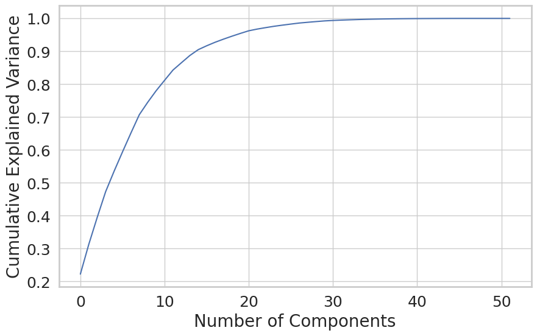

```python
from sklearn.decomposition import PCA
import matplotlib.pyplot as plt
# find best pca component number to represent feature
pca = PCA().fit(X_train_normal_only)
plt.plot(np.cumsum(pca.explained_variance_ratio_))
plt.xlabel('Number of Components')
plt.ylabel('Cumulative Explained Variance')
n_components_95 = np.where(np.cumsum(pca.explained_variance_ratio_) >= 0.95)[0][0] + 1
print(f"To explain 95% variance, we need {n_components_95} components.")
print(n_components_95)
pca_best_nu = PCA(n_components=n_components_95)
# use pca to compass our train dataset (normal only)
X_train_pca_normal_only = pca_best_nu.fit_transform(X_train_normal_only)
X_test_pca_mixed = pca_best_nu.transform(X_test_tensor.cpu().numpy())
print(f"Original Training Shape: {X_train_normal_only.shape}")
print(f"Compressed Training Shape: {X_train_pca_normal_only.shape}")
print(f"Compressed Test Shape: {X_test_pca_mixed.shape}")

ocsvm_pca = OneClassSVM(kernel='rbf', nu=optimal_nu, gamma='scale')
# We train the OC-SVM using only the embeddings derived from the normal samples in the training set.
print("Training OC-SVM on bottleneck embeddings...")
ocsvm_pca.fit(X_train_pca_normal_only)
raw_test_preds_pca = ocsvm_pca.predict(X_test_pca_mixed)
final_test_preds_pca = np.where(raw_test_preds_pca == 1, 0, 1)
# === 2. Evaluate Performance on Test Set ===
print("Classification Report for OC-SVM on oc_svm pca Features:")
print(classification_report(y_test, final_test_preds_pca, digits=4))
```

# Task 4: Unsupervised Anomaly Detection and Interpretation

## K-means with little domain knowledge: As a domain expert, you may know the number of common attacks on your network, but not their actual attack label. Under this assumption, fit k-means with 4 clusters and the full training data (normal + anomalous).

```python
# Function to compute SSE (Sum of Squared Errors)
from matplotlib import cm
from sklearn.metrics import silhouette_samples, silhouette_score

def compute_sse(X, centroids, labels):
    """
    Compute the Sum of Squared Errors (SSE) for a given clustering.

    Parameters:
    - X : ndarray of shape (n_samples, n_features)
        The input data.
    - labels : array-like of shape (n_samples,)
        Cluster labels assigned to each point. Should not contain -1.

    Returns:
    - sse : float
        The SSE (sum of squared distances to cluster centroids).
    """
    unique_labels = np.unique(labels)
    sse = 0.0

    for label in unique_labels:
        if label == -1:
            continue  # Skip noise points (e.g., in DBSCAN)
        cluster_points = X[labels == label]
        centroid = centroids[label]#cluster_points.mean(axis=0)
        sse += np.sum((cluster_points.values - centroid) ** 2)

    return sse


def compute_silhouette_details(X, labels):
    # Remove noise points if any (e.g., DBSCAN)
    mask = labels != -1
    X_clean = X[mask]
    labels_clean = labels[mask]

    # Compute overall silhouette score
    silhouette_avg = silhouette_score(X_clean, labels_clean)

    # Compute per-sample silhouette scores
    sample_silhouette_values = silhouette_samples(X_clean, labels_clean)

    # Aggregate by cluster
    cluster_silhouettes = {}
    for cluster in np.unique(labels_clean):
        cluster_silhouettes[cluster] = sample_silhouette_values[labels_clean == cluster].mean()

    return silhouette_avg, cluster_silhouettes, sample_silhouette_values


def plot_silhouette(silhouette_avg,sample_silhouette_values,cluster_labels):

    distinct_labels = set(cluster_labels)
    n_clusters = len(distinct_labels)
    if(-1 in distinct_labels):
        n_clusters -=1

    print("For n_clusters =",n_clusters,"The average silhouette_score is :",silhouette_avg)

    fig, ax = plt.subplots(figsize=(8, 6))

    y_lower = 10

    for i in range(n_clusters):

        # Aggregate the silhouette scores for samples belonging to
        # cluster i, and sort them
        ith_cluster_silhouette_values = sample_silhouette_values[cluster_labels == i]
        print("cluster",i,"size",len(ith_cluster_silhouette_values))
        ith_cluster_silhouette_values.sort()

        size_cluster_i = ith_cluster_silhouette_values.shape[0]
        y_upper = y_lower + size_cluster_i

        color = cm.nipy_spectral(float(i) / n_clusters)
        ax.fill_betweenx(
            np.arange(y_lower, y_upper),
            0,
            ith_cluster_silhouette_values,
            facecolor=color,
            edgecolor=color,
            alpha=0.7,
        )

        # Label the silhouette plots with their cluster numbers at the middle
        ax.text(-0.05, y_lower + 0.5 * size_cluster_i, str(i))

        # Compute the new y_lower for next plot
        y_lower = y_upper + 10  # 10 for the 0 samples



    ax.set_title("The silhouette plot for the various clusters.")
    ax.set_xlabel("The silhouette coefficient values")
    ax.set_ylabel("Cluster label")

    # The vertical line for average silhouette score of all the values
    ax.axvline(x=silhouette_avg, color="red", linestyle="--")

    ax.set_yticks([])  # Clear the yaxis labels / ticks
    ax.set_xticks([-0.1, 0, 0.2, 0.4, 0.6, 0.8, 1])

    plt.show()
    plt.close()
    return
```

## Q: How big are the clusters? How are the attack labels distributed across the clusters?Are the clusters pure (i.e., they consist of only one attack label)?

```python
from sklearn.cluster import KMeans
# define total clusters labels for KMeans = 4 since we have 4 attack categories in our dataset
labels_count = df_train_preprocessed['label'].nunique()
print("Unique attack labels for KMeans:", labels_count)

len_X_train=len(X_train)
print("Number of samples in training set:", len_X_train)

kmeans = KMeans(n_clusters=(labels_count), random_state=42)#since we have 4 attack categories, we can try to see if KMeans can find them
kmeans_labels = kmeans.fit_predict(X_train)
print("number of clusters:\n", len(kmeans.cluster_centers_))
cluster_labels = kmeans.labels_
print("Cluster labels assigned by KMeans:\n", np.unique(cluster_labels))
# get the unique cluster labels and their counts
unique_labels, counts = np.unique(kmeans_labels, return_counts=True)
for label, count in zip(unique_labels, counts):
    print(f"cluster {label} contains {count} data points")

comparison_df = pd.DataFrame({
    'kmeans_label': kmeans_labels,
    'original_label': y_original_train
})

# 1. Calculate raw counts (frequencies)
ct_counts = pd.crosstab(comparison_df['kmeans_label'], comparison_df['original_label'])

# 2. Calculate percentages (normalized by row/index)
ct_ratios = pd.crosstab(comparison_df['kmeans_label'], comparison_df['original_label'], normalize='index')

# 3. Combine both into a single string-formatted table
ct_combined = ct_counts.copy().astype(str) # Convert to string type first to allow mixed formatting

for row in ct_counts.index:
    for col in ct_counts.columns:
        count = ct_counts.loc[row, col]
        percentage = ct_ratios.loc[row, col] * 100
        # Format as: count (percentage%)
        ct_combined.loc[row, col] = f"{count} ({percentage:.1f}%)"

print("--- Cluster Counts and Percentages Comparison Table ---")
print(ct_combined)

#sse_avg = compute_sse(X_train,kmeans.cluster_centers_,kmeans_labels)
#silhouette_avg, clusters_silhouettes, sample_silhouette_values = compute_silhouette_details(X_train, kmeans_labels)

#print(f"K-Means SSE: {sse_avg:.2f}")
#print(f"K-Means Silhouette Score: {silhouette_avg:.2f}")
#plot_silhouette(silhouette_avg,sample_silhouette_values,cluster_labels)
```

```
Unique attack labels for KMeans: 4
Number of samples in training set: 16917
number of clusters:
 4
Cluster labels assigned by KMeans:
 [0 1 2 3]
cluster 0 contains 13618 data points
cluster 1 contains 1590 data points
cluster 2 contains 1701 data points
cluster 3 contains 8 data points
--- Cluster Counts and Percentages Comparison Table ---
original_label           dos         normal        probe         r2l
kmeans_label
0                 829 (6.1%)  11580 (85.0%)  1056 (7.8%)  153 (1.1%)
1               1486 (93.5%)      31 (1.9%)    72 (4.5%)    1 (0.1%)
2                301 (17.7%)    484 (28.5%)  916 (53.9%)    0 (0.0%)
3                   0 (0.0%)     8 (100.0%)     0 (0.0%)    0 (0.0%)
```